# EP01-respuesta-equipo-8

Patricio Durán

2025-08-22

```r
if(!require(dplyr)) install.packages("dplyr")
if(!require(ggpubr)) install.packages("ggpubr")
if(!require(modeest)) install.packages("modeest")
```

En el siguiente documento se busca responder la siguiente pregunta:

¿Cómo diría que es el ingreso de las mujeres de la RM? (simétrico/asimétrico, concentrado/disperso, unimodal/multimodal, etc.)

```r
datos <- read.csv("EP01 Datos Casen 2017.csv", header = TRUE, sep = ";") #Carga de datos
```

Para la resolución del problema se trabajará con las variables “sexo”, “edad” e “ytot”, ya que se debe analizar el ingreso total de las mujeres, además de verificar que solo se tomen datos de mayores de edad. Al correr el código anterior para cargar el archivo .csv, se puede observar que las variables a utilizar se muestran correctamente en el dataset. A continuación, se mostrará una tabla indicando el tipo de cada variable y la escala en que se mide.

```r
variables <- data.frame(
  ID = 1:3,
  NombreVariable = c("sexo", "edad", "ytot"),
  Descripción = c("Género de la persona", "Edad de la Persona", "Ingresos Totales de la persona"),
  Tipo = c("Númerica Discreta", "Categórica Ordinal", "Categórica Discreta"),
  Escala = c("Nominal", "De razón", "De razón")
)
print(variables)
```

[output not shown]

Luego, se hará el filtro de los datos para poder trabajar con ellos

```r
mujeres <- datos %>% filter(sexo=="Mujer") #Filtrar datos por sexo femenino
mujeresMayoresDeEdad <- mujeres %>% filter(edad >= 18) #Filtrar datos por mujeres mayores de edad
```

Para el análisis, se hará uso de dos histogramas, el primero será para mostrar la distribución completa de los datos, mientras que el segundo tendrá el propósito de mostrar con mayor claridad la concentración de los valores.

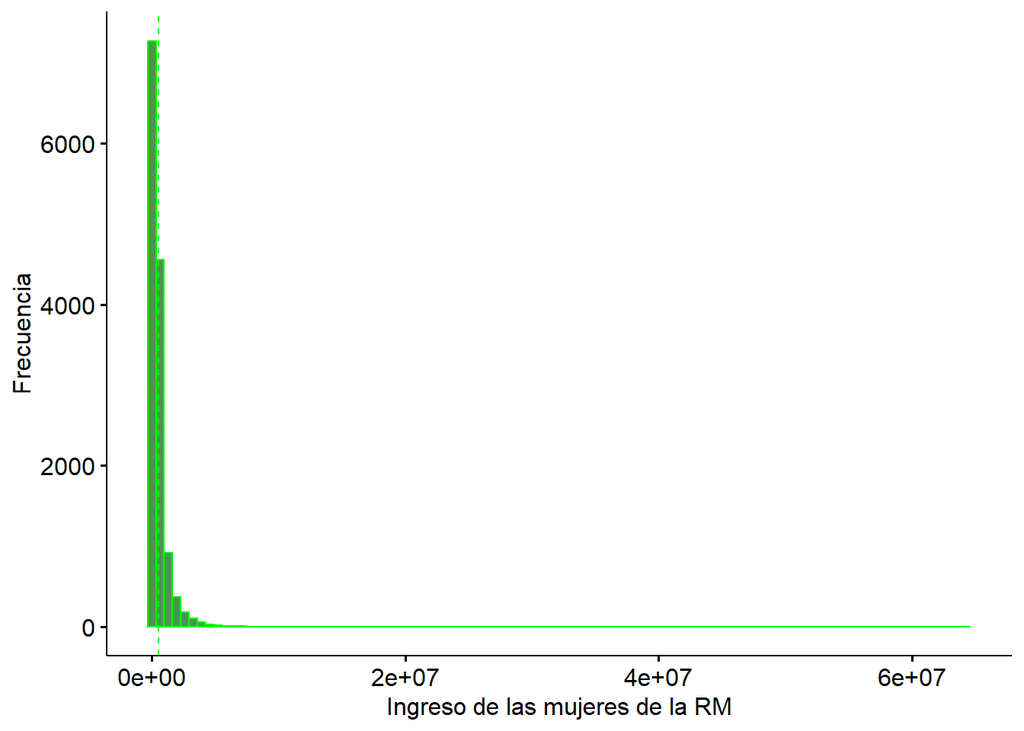

```r
#Generar primer histograma
histograma1 <- gghistogram(mujeresMayoresDeEdad, x = "ytot", bins = 100, add = "mean",
                          color = "green", fill = "darkgreen", alpha = 0.7,
                          xlab = "Ingreso de las mujeres de la RM", ylab = "Frecuencia")
print(histograma1)
```

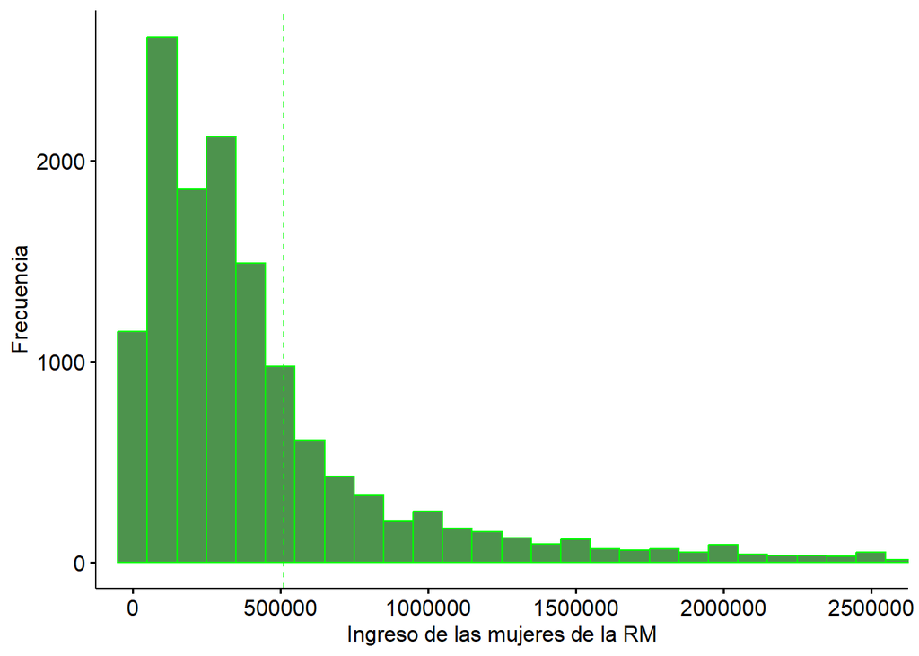

```r
#Generar segundo histograma
histograma2 <- gghistogram(mujeresMayoresDeEdad, x = "ytot", binwidth = 100000, add = "mean", xlim = c(0,2500000),
                          color = "green", fill = "darkgreen", alpha = 0.7,
                          xlab = "Ingreso de las mujeres de la RM", ylab = "Frecuencia")
print(histograma2)
```

Además, se calculará la moda, para verificar si la distribución de datos es unimodal, bimodal o multimodal

```r
ingresosM <- mujeres$ytot #Filtrar ingresos

#Calcular moda
#La siguiente formula retorna un valor único en caso de haber solo una moda, caso contrario, retorna un vector con todas las modas
modas <- mlv(ingresosM, method = "mfv")
print(modas)
```

```
## [1] 11091
```

#Conclusión

En base a los histogramas, se observa que los ingresos se concentran a la izquierda, por lo que se puede decir que su distribución tiene asimetría positiva o que está desviada hacia la derecha.

Además, los datos se concentran principalmente en valores bajos, esto se ve más claro en el segundo histograma, donde la mayor acumulación parece rondar los 100000 y 300000 aproximadamente, mientras que desde los 500000 comienza a notarse una marcada disminución en la frecuencia de los datos.

En cuanto al primer histograma, ayuda a evidenciar que la distribución de datos es muy dispersa, debido a la presencia de valores extremadamente altos.